# Zero-inflated Poisson Analysis of Flicker Counts

BIO 133

Eric R. Scott

# Packages

```r
library(tidyverse)
library(here) # for here()
library(pscl) #for zero-inflated poisson
library(MASS) #for rnegbin() and other useful functions
# the MASS package has a function `select()` just like dplyr in the tidyverse.  If you want to always use the dplyr version you could do:

select <- dplyr::select

#for map (optional):
library(maps)
library(mapproj)
```

# Data

```r
# data for map
new_england <- map_data('state', region = c('massachusetts', 'new hampshire', 'vermont', 'maine', 'connecticut', 'rhode island'))

birds <- read_csv(here("data", "NE_flickers.csv"))
head(birds)
```

| Code | Name | Latitude | Longitude | hours | Count |
| --- | --- | --- | --- | --- | --- |
| CTBA | Barkhamsted | 41.9123 | -72.9884 | 72.50 | 0 |
| CTEW | Edwin Way Teale Trail Wood | 41.7966 | -71.9274 | 48.50 | 0 |
| CTGS | Greenwich-Stamford | 41.0826 | -73.6138 | 182.50 | 53 |
| CTHA | Hartford | 41.7660 | -72.6727 | 198.00 | 0 |
| CTLH | Litchfield Hills | 41.7703 | -73.2724 | 69.95 | 0 |
| CTLS | Lakeville-Sharon | 41.9449 | -73.4399 | 49.50 | 0 |

# Fun code for making a map with ggplot2

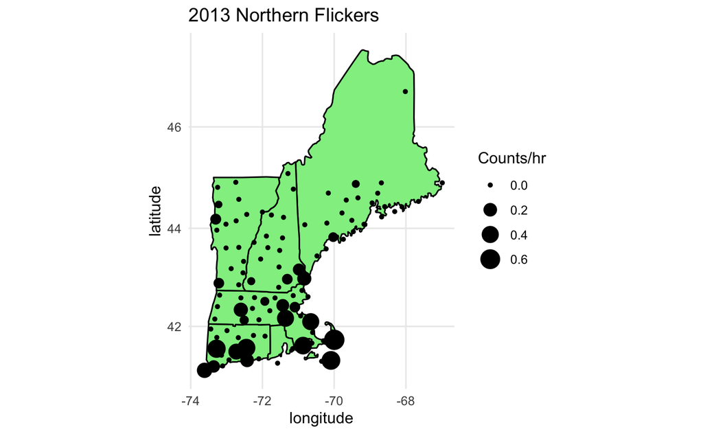

```r
ggplot() +
  geom_polygon(data = new_england, aes(x = long, y = lat, group = group),
               color = "black", #lines
               fill = "lightgreen") + #area
  geom_point(data = birds, aes(x = Longitude, y = Latitude, size = Count/hours)) +
  coord_map() +
  theme_minimal() +
  labs(title = "2013 Northern Flickers", x = "longitude", y = "latitude", size = "Counts/hr")
```

# Simple poisson glm

```r
m1 <- glm(Count ~ 1, family = poisson, data=birds)
# expected # of flickers, simple poisson model:
coef(m1) # ... on a log scale
```

```
(Intercept)
   1.768618
```

```r
exp(coef(m1)) # .... back-transformed
```

```
(Intercept)
   5.862745
```

## Expected distribution if simple Poisson

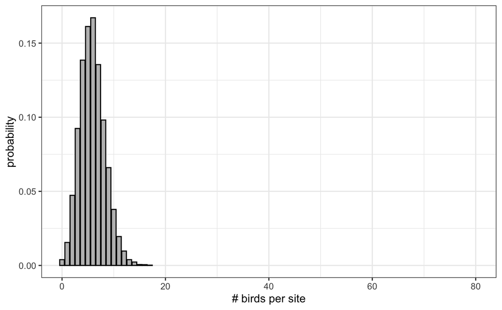

## Actual distribution

Plot the data as a histogram / bar chart

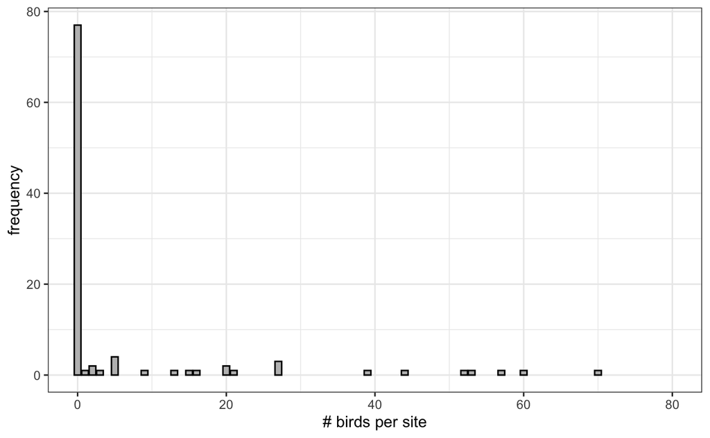

```r
ggplot(birds, aes(Count)) +
  geom_bar(color = "black", fill = "grey") +
  theme_bw() +
  coord_cartesian(xlim = c(0, 80)) +
  labs(y = "frequency", x = "# birds per site")
```

# Zero-inflated Poisson GLM

```r
m2 <- zeroinfl(Count ~ 1, data = birds)
coef(m2)
```

```
count_(Intercept)  zero_(Intercept)
         3.174715          1.124927
```

```r
plogis(coef(m2)[2])
```

```
zero_(Intercept)
       0.7549016
```

75% probability habitat is unsuitable

```r
exp(coef(m2)[1]) # expected # of flickers, in suitable sites
```

```
count_(Intercept)
            23.92
```

23.92 = expected # of flickers, in suitable sites

## Expected distribution if ZiP

75% zeros, 25% draws from poisson with mean of 23.9

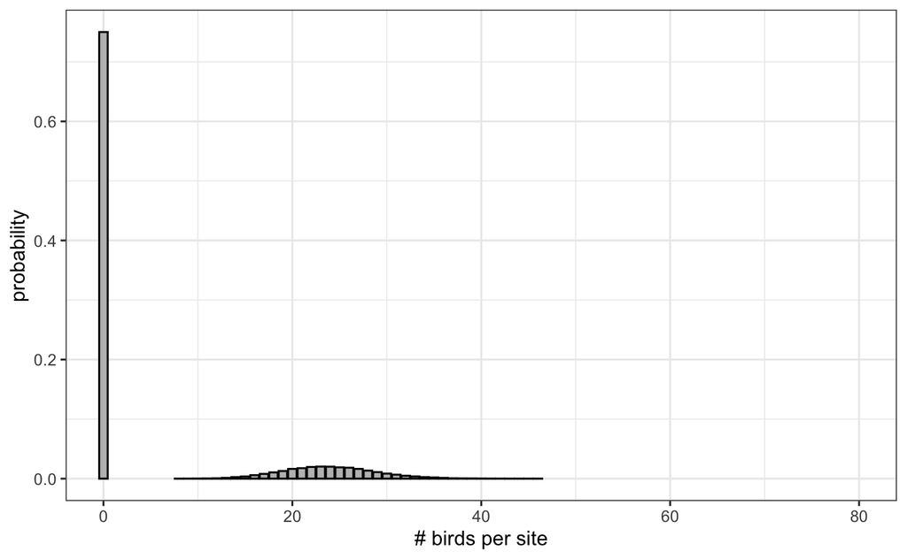

```r
zip_pred_a = rep(0, 75000) #zeroes
zip_pred_b = rpois(25000, exp(coef(m2)[1])) #poisson
zip_pred = data.frame(x = c(zip_pred_a, zip_pred_b))

ggplot(zip_pred) +
  geom_bar(stat = "count", aes(x, y= ..prop.., group = 1),
           fill = "grey", color = "black") +
  theme_bw() +
  coord_cartesian(xlim = c(0, 80)) +
  labs(y = "probability", x = "# birds per site")
```

Variance higher than mean, because this isn’t just Poisson:

```r
mean(zip_pred$x)
```

```
[1] 5.98017
```

```r
var(zip_pred$x)
```

```
[1] 113.29
```

## Adding an offset

one more possible source of sampling error: hours of observation

```r
head(birds)
```

| Code | Name | Latitude | Longitude | hours | Count |
| --- | --- | --- | --- | --- | --- |
| CTBA | Barkhamsted | 41.9123 | -72.9884 | 72.50 | 0 |
| CTEW | Edwin Way Teale Trail Wood | 41.7966 | -71.9274 | 48.50 | 0 |
| CTGS | Greenwich-Stamford | 41.0826 | -73.6138 | 182.50 | 53 |
| CTHA | Hartford | 41.7660 | -72.6727 | 198.00 | 0 |
| CTLH | Litchfield Hills | 41.7703 | -73.2724 | 69.95 | 0 |
| CTLS | Lakeville-Sharon | 41.9449 | -73.4399 | 49.50 | 0 |

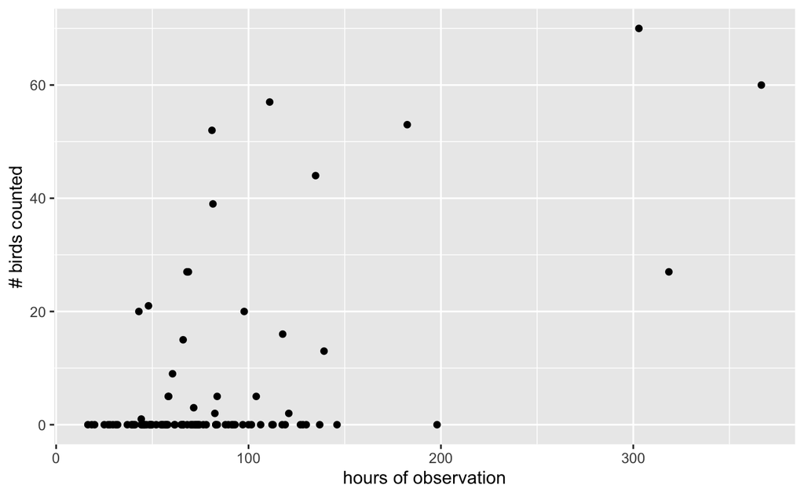

```r
#does number of birds increase with search effort?
ggplot(birds, aes(x = hours, y = Count)) + geom_point() +
  labs(x = "hours of observation", y = "# birds counted")
```

Distribution of counts per 100 hours:

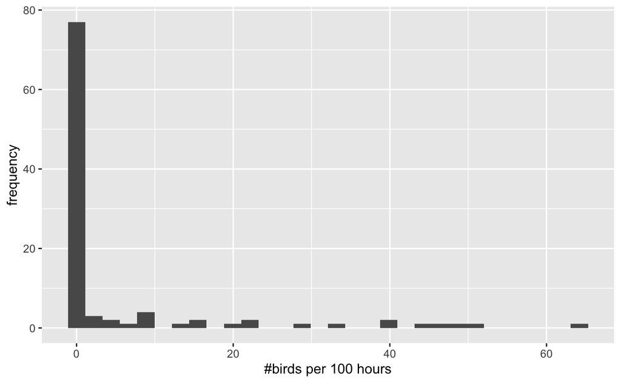

```r
birds <- birds %>%
  mutate(count_per_hr = Count/hours)

ggplot(birds, aes(count_per_hr*100)) +
  geom_histogram() +#histogram for continuous data
  labs(y = "frequency", x = "#birds per 100 hours")
```

```r
mean(100*birds$count_per_hr)
```

```
[1] 5.506835
```

```r
var(100*birds$count_per_hr)
```

```
[1] 174.2383
```

Use an offset to model birds per hour

```r
m3 <- zeroinfl(Count ~ 1, offset = log(hours), data = birds)
coef(m3)
```

```
count_(Intercept)  zero_(Intercept)
        -1.583036          1.123325
```

```r
plogis(coef(m3)[2]) # probability habitat is unsuitable
```

```
zero_(Intercept)
       0.7546049
```

```r
exp(coef(m3)[1]) # expected # of flickers, per hour of observation
```

```
count_(Intercept)
        0.2053506
```

**NOTE**: Using `predict()` gives you just estimated counts. These are the expected *numbers of birds*, **NOT** birds per hour. The `predict()` function “knows” about the offset.

```r
predict(m3, type = "response") %>% head()
```

```
       1        2        3        4        5        6
3.653422 2.444013 9.196545 9.977622 3.524922 2.494405
```

## Predicted distribution if ZiP with offset

75% zeros, 25% draws from pooisson with mean of 20.5 birds per 100 hrs (0.205 birds per hour).

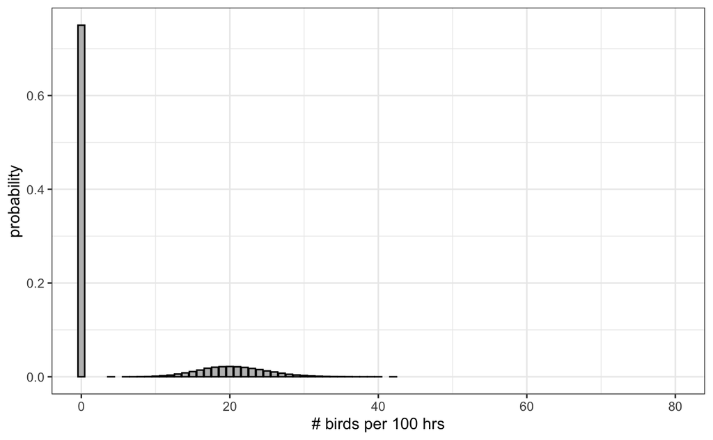

```r
zip_pred_c = rep(0, 75000)
zip_pred_d = rpois(25000, 100*exp(coef(m3)[1]))
zip_pred2 = tibble(x = c(zip_pred_c, zip_pred_d))

#copy and paste code, change dataframe name:
ggplot(zip_pred2) +
  geom_bar(stat = "count", aes(x, y= ..prop.., group = 1),
           fill = "grey", color = "black") +
  theme_bw() +
  coord_cartesian(xlim = c(0, 80)) +
  labs(y = "probability", x = "# birds per 100 hrs")
```

```r
mean(zip_pred2$x)
```

```
[1] 5.12843
```

```r
var(zip_pred2$x)
```

```
[1] 84.09056
```

# Zero-inflated negative binomial

Assumes the count portion of model is not single poisson, but combination of poissons = negative binomial distribution.

```r
m4 <- zeroinfl(Count ~ 1, offset = log(hours), dist = "negbin", data = birds)
summary(m4)
```

```
Call:
zeroinfl(formula = Count ~ 1, data = birds, offset = log(hours), dist = "negbin")

Pearson residuals:
    Min      1Q  Median      3Q     Max
-0.3980 -0.3932 -0.3896 -0.3703  4.1963

Count model coefficients (negbin with log link):
            Estimate Std. Error z value Pr(>|z|)
(Intercept)  -1.5615     0.2009  -7.771 7.76e-15 ***
Log(theta)    0.1100     0.3954   0.278    0.781

Zero-inflation model coefficients (binomial with logit link):
            Estimate Std. Error z value Pr(>|z|)
(Intercept)    1.033      0.245   4.215  2.5e-05 ***
---
Signif. codes:  0 '***' 0.001 '**' 0.01 '*' 0.05 '.' 0.1 ' ' 1

Theta = 1.1163
Number of iterations in BFGS optimization: 13
Log-likelihood: -157.2 on 3 Df
```

Negative binomial defined by two parameters: mean and theta, a dispersion parameter. Theta = 1.1163

## Predicted distribution if zero-inflated negative binomial

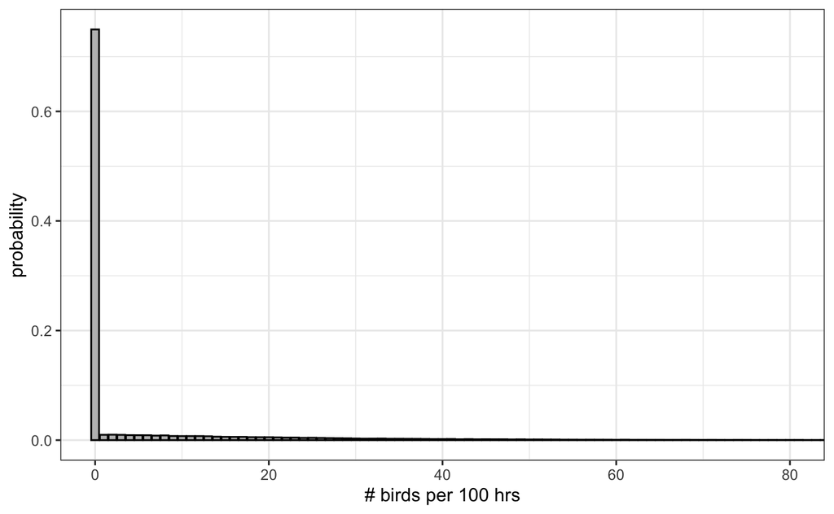

```r
zinb_pred_a = rep(0, 74000) # probability of zeros = 0.74; 74% are 0's
zinb_pred_b = rnegbin(26000, mu = 100 * exp(coef(m4)[1]), theta = m4$theta)

# prob of non-zeros = 0.26; 26% are samples from a negative binomial distribution with count and dispersion terms from the fitted model

zinb_pred = tibble(x = c(zinb_pred_a, zinb_pred_b)) # combined data from both  distributions

ggplot(zinb_pred) +
  geom_bar(stat = "count", aes(x, y= ..prop.., group = 1),
           fill = "grey", color = "black") +
  theme_bw() +
  coord_cartesian(xlim = c(0, 80)) +
  labs(y = "probability", x = "# birds per 100 hrs")
```

```r
mean(zinb_pred$x)
```

```
[1] 5.49611
```

```r
var(zinb_pred$x)
```

```
[1] 194.2866
```

# Which model is best?

Use AIC to compete a simple poisson, a zero-inflated poisson, and a zero-inflated negative binomial model with an offset of hours. Decide which probability distribution best explains the data.

[output not shown]

The zero-inflated negative binomial has the lowest AIC and it the best of the three distributions for modeling the data.